# R Project Milestone 6

Moyra Rasheed, Courtney Coon, Jarett Maycott

2022-11-28

# **Problem Statement**

Rural hospitals are struggling to stay open throughout the country and the state of California ranks #4 in rural hospital closures ([citation](https://kesq.com/stacker-california/2021/12/09/california-is-the-4-state-with-the-most-rural-hospital-closures-since-2005/)). When rural hospitals close, there is a subsequent rise in mortality ([citation](https://www.nber.org/papers/w26182?utm_campaign=ntwh&utm_medium=email&utm_source=ntwg12)). This is why the California Department of Public Health, Office of Health Equity is excited that a new policy has just been created to fund a public-private partnership for healthcare facility improvement in 5 of California’s rural counties that have received minimal funding from the Department of Health Care Access and Information (HCAI) over the past 5 years. Here we have analyzed 5 variables in order to determine which 5 counties are the best targets for the development fund proposals.

# **Methods**

### **Data Sources**

To make recommendations on target counties, we used variables from three open-access, State of California data sources which are described below.

#### *[California demographics by County](https://github.com/PHW290/phw251_projectdata/blob/main/ca_county_demographic.csv)*

Includes data on population characteristics by county including average population density, counts by race/ethnicity, sex, median age, and housing data.

**Years and/or dates of data**

Data was collected in 2012.

**Description of cleaning and creating new variables**

To prepare the data, we:

1. Data cleaning
- make “County” the first (left-most) column in the data set for merging
2. Data filtering
- subset data to only include needed data
3. Data summarizing
- *NEW VARIABLE*: categorize Median Age into “High Priority” (counties with Median Age above the third quantile), “Medium Priority” (counties with Median Age between the first and third quantiles), and “Low Priority” (counties with Median Age below the first quantile)
- *NEW VARIABLE*: categorize Population per Square Mile (hereafter Population Density) into “High Priority” (counties with Population Density above the third quantile), “Medium Priority” (counties with Population Density between the first and third quantiles), and “Low Priority” (counties with Population Density below the first quantile)
- *NEW VARIABLE*: create ratio of renting households as a fraction of total households.
- *NEW VARIABLE*: categorize Percent of Household that were Renters (hereafter Percent Renters) into “High Priority” (counties with Percent Renters above the third quantile), “Medium Priority” (counties with Percent Renters between the first and third quantiles), and “Low Priority” (counties with Percent Renters below the first quantile)

#### *[California Department of Public Health Care: Death Profiles by County](https://data.ca.gov/dataset/death-profiles-by-county)*

Includes data on mortality events stratified by age, sex, race, hospital department, and residence status of the deceases relative to the hospital where the mortality event occurred.

**Years and/or dates of data**

The data set contains data from 2014 through 2020.

**Description of cleaning and creating new variables**

To prepare the data, we:

1. Data cleaning
- made all column names lowercase
- replaced NAs with zeros, as instructed
2. Data filtering
- filtered data in “strata_name” to only include data about the Total Population (removed age, sex, race and other stratifiers)
- filtered out non-chronic diseases (all cause, assault, accidents, influenza and self-harm)
- removed data from 2014
3. Data summarizing
- *NEW VARIABLE*: sum all chronic disease mortality events by county
- *NEW VARIABLE*: [after merging data sets] divide summed chronic disease mortality by average population size (from the demographic data set) to create a rate of chronic disease mortality per person for each county
- *NEW VARIABLE*: categorize Chronic Disease Mortality Rates (hereafter Mortality) into “High Priority” (counties with Mortality above the third quantile), “Medium Priority” (counties with Mortality between the first and third quantiles), and “Low Priority” (counties with Mortality below the first quantile)

#### *[Department of Health Care Access and Information: Total Construction Cost of Healthcare Projects](https://data.ca.gov/dataset/total-construction-cost-of-healthcare-projects)*

Includes number of projects and total spending on hospital projects funded by Department of Health Care Access and Information (HCAI) by county, date, and project status (“in review”, “pending construction”, “in construction” and “in closure.”)

**Years and/or dates of data**

The original data set contains data from 10-14-2013 through 08-11-2022.

**Description of cleaning and creating new variables**

To prepare the data, we:

### **Analytic methods**

We decided to approach the ranking of counties with two different techniques to examine the robustness of our final recommendations. Our first approach was to use to two graphs. In the first graph would be a scatterplot where we would use just the 3 demographic variables to identify top priority counties with fraction of renters on the x-axis, median age of the residents on the y-axis and dots to color code populations as being high or low priority based on population density (lower density was higher priority).

To prepare for our second scatterplot, we collapsed the ranking data from the first scatterplot into a single data set by coding a *NEW VARIABLE* where we gave 2 points to variables identified as “high priority,” 1 point for variables identified as “medium priority” and zero points for “low priority” variables for each county. For example, Amador County is a high priority population based on median age (2 points) and population density (2 more points) but a low priority population based on proportion of residents that were renters (0 points) for a total demographic ranking score of 4 points. This 6th variable was used to color code the dots in the second scatterplot where we had Total Cost of Previous and Ongoing OSHPD/HCAI project on the x-axis and Relative Levels of Chronic Disease Mortality Events on the y-axis. This second graph highlights the counties that we would consider recommending for future priority funding because it includes all 5 variables of interest.

# **Results**

### *Figure 1:*

Here we identified high priority counties based on demographic data only with priority given to counties with: (1) renter ratios above the median of all counties (median = 39%), (2) median population age above the median for all counties (median = 37 years old), and (3) population densities below the third quantile for all counties (High priority is below the 1st quantile = 26 people per square mile; Low priority is above the 3rd quantile = 333 people per square mile). Each dot represents a county in California. Counties that are named on the figure are those meeting all of the high priority demographic criteria.

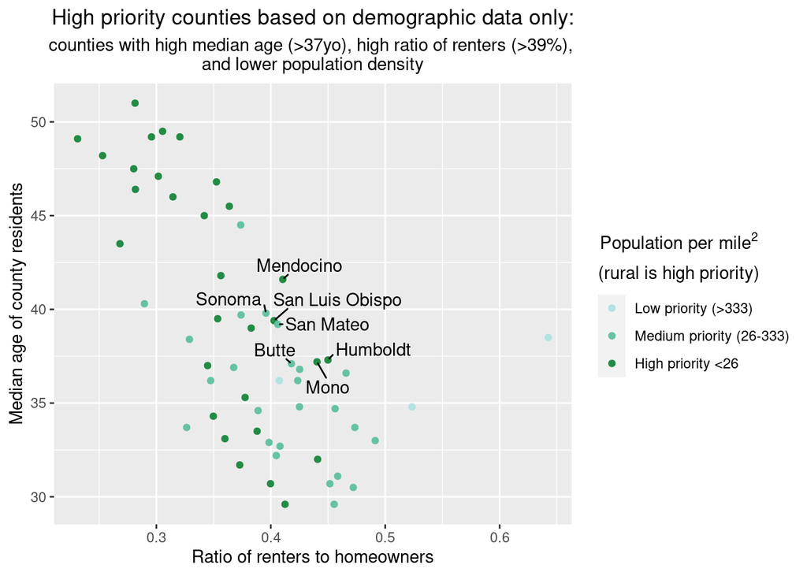

### *Figure 2:*

Here we identified high priority counties using all variables of interest. The color coding is based on the demographic data presented in Plot 1. A County with higher priority demographic values for each variable received a higher score than a county with lower priority values (score of 4 has the highest priority). Also in the Plot is the total dollars previously invested in prior projects with higher priority for counties below the median previous investment (log($5,961,782,208) = 22.50864) on the x-axis, and, on the y-axis, rate of chronic disease mortality events between 2015-2020, with higher priority counties having higher than the median rates of chronic disease mortality (median=0.07 cases of mortality per person).

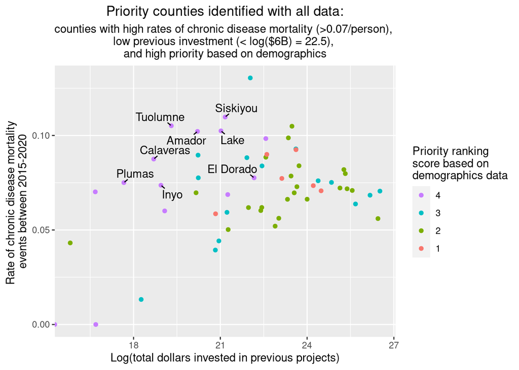

### *Table:*

[output not shown]

[output not shown]

The ranking variable described in the Analytic Methods identifies 3 Counties as top priorities - Lake, Nevada, and Siskiyou - and 3 more Counties as second-rank priorities - Amador, Calaveras, and Tuolumne.

# **Discussion**